# Part II - Effects of Loan's and Borrowers' Characteristics on The Loan Status

## by Manuk Mikayelyan

## Investigation Overview

> In this investigation, we wanted to look at the characteristics of loans and borrowers that could be used to predict the loan status. The main focus will be on employements status, dept to Income ratio, prosper rating, recommedations, and loan amount.

## Dataset Overview

> This dataset contains information regarding 113937 prosper loan data which includes loan status and other attributes such as borrower rate (or interest rate), employment status, recommendations count, borrower income, and many others. The dataset was subset for only values of loan status that includes Completed, Defaulted or chargedOff. 871 duplicate records have been identified and drouped out from the dataset.

## Loan portfolio distribution by loan status

> The vast majority of lones belong to `Completed` category (over 71.12% of records). `Charged off` loans also have a notable share (around 21.8% of records) followed by `Defaulted` (about 7.08%).

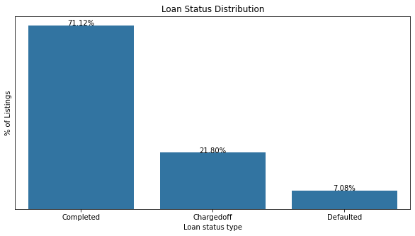

## Distribution of ProsperRating

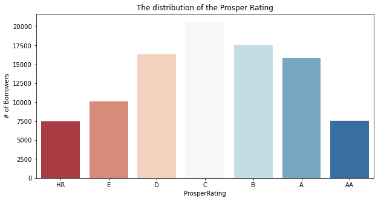

## Distribution of Debt-to-Income ratio

> The distribution of Debt-to-Income ratio is right skewed. Most borrowers who apply for a loan have a debt to income ratio around 20%. There are some drops in counts as the ratio approaches 0.4 and 0.6.

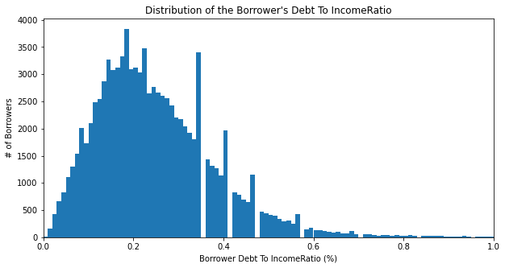

## Distribution of IncomeRange

> The vast majority of the borrowers have income in the range 25K-75K.

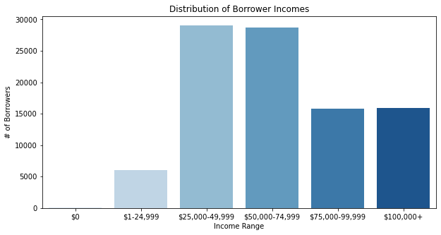

## Recommendations by Loan Status

> Most of the people granted loans have less than ten recommendations count for completed, defaulted and chargedoff status. At the same time there are more completed loans with recommendations more than 10 than there are for defaulted and charged off.

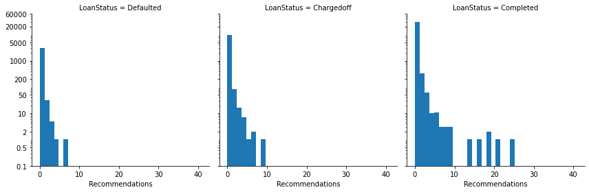

## BorrowerAPR and ProsperRating by Loan Status

> Borrowers with high ratings receive loans at lower interest rates and also have a lower risk of default. Among defaulted AA borrowers, the default rate was higher compared to ChargedOff and Completed categories.

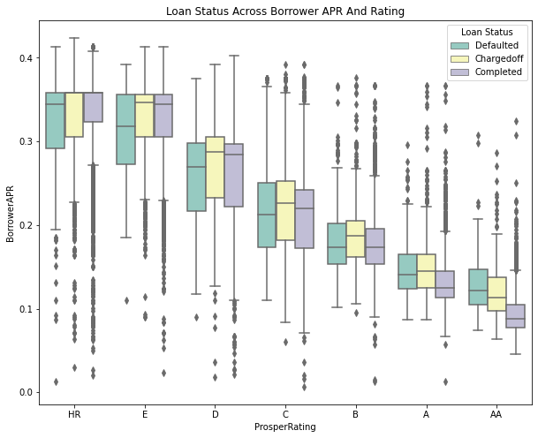

## Loan Original Amount and ProsperRating by Loan Status

> Borrowers with high ratings receive greater amount of loans for which the risk of default is higher as well.

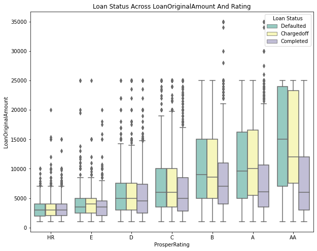

## Loan Original Amount and BorrowerAPR by Loan Status

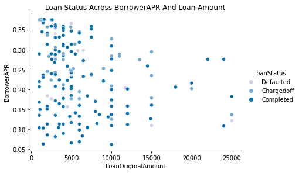

## Employment Status and Listing Category by Loan Status

> Those borrowers who are fully employed seem to borrow for a wide range of reasons with some having equal chances of being charged off or defaulted as they have of being completed. Those borrowers who are not employed or part-time employed seem to mainly borrow for a study, dept consolidation reasons again having equal chances of being charged off or defaulted as they have of being completed.

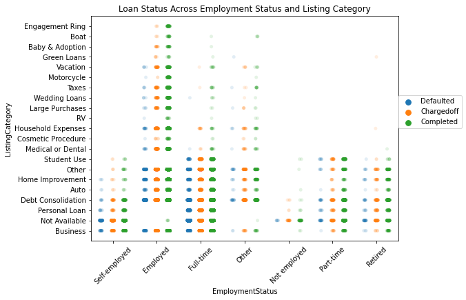

## Employment Status and Recommendations by Loan Status

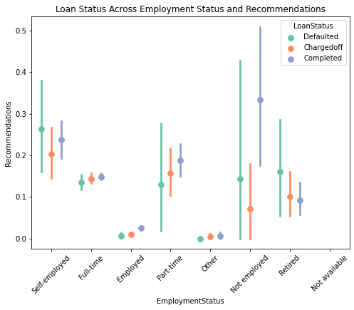